# City-level innovation spillovers: global vs. LMICs (excl. China)

Innovation Strategy Explorer — insights

2026-04-30

## What this note shows

For every city in the app’s `countrymap`, two per-city averages are computed:

- **Average Global Spillover** — the mean of `ev_global` (Watson average global spillover per patent family) across all docdbs mapped to the city.
- **Average Spillover to LMICs (excl. China)** — the mean of `ev_emdenocn` across the same docdbs, i.e. the share of those spillovers that land in low- and middle-income countries other than China.

The scatter plot below shows one dot per city. A linear trend line summarises the overall relationship; the largest cities (by patent count) are highlighted, and a hand-picked list of LMIC / mid-tier cities is always labelled regardless of size.

```
## cities seen: 10,716   (median patents/city: 14, max: 158,279, share_green median: 2.5%)
```

## City selection

To stop the scatter from being dominated by tiny cities with one outlier patent, we keep only those with at least `min_patents` distinct patent families. **The hand-picked label set is always kept, regardless of size** — otherwise small LMIC cities (Belém has only ~14 families, Luang Prabang fewer still) would be dropped from the plot and from the abstract-summary section before they can be flagged.

The patent universe here is the **“All innovations”** view: every docdb in `patent_database` with a non-null `ev_global`, no tech filter and no granted-only filter. This matches the HiGGlo “All innovations” tab counts exactly — e.g. Belém: 14 families total, 8 granted.

```
## after filter (>= 10 patents OR in required list): 6,159 cities kept (57.5% of all)
```

```
## # A tibble: 7 × 2
##   pattern                                matches
##   <chr>                                  <chr>
## 1 Bogot[aá]                              "Bogota"
## 2 Bel[eé]m                               "Belem"
## 3 Ibadan                                 "Ibadan"
## 4 Konya                                  "Konya"
## 5 Antalya|Antaya                         "Antalya, Daanbantayan"
## 6 Sofia|Sofiya                           "Sofia"
## 7 Luang ?Prabang|Luangprabang|Luanpraban ""
```

## Scatter plot

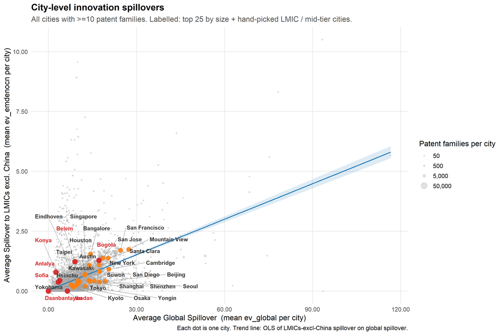

## Trend-line fit

```
## OLS:  avg_ev_emdenocn = 0.0299 + 0.0495 * avg_ev_global
##   R^2 = 0.219, n = 6159 cities
```

## Scatter: green-tech spillover vs overall spillover

For every city we now have **two** average global-spillover numbers: the overall mean across all of its docdbs, and the mean restricted to docdbs flagged as Green Technology. Plotting them against each other shows whether a city’s green innovations punch above or below its overall innovation-spillover footprint. The dashed grey line is the 1:1 reference — points above it are cities whose green innovations generate higher-than-average global spillover for that city; points below sit on the other side of the gap.

Cities with zero green docdbs drop out of this view automatically (no green mean to plot). The same big-city anchors and hand-picked LMIC cities are highlighted as in the first scatter.

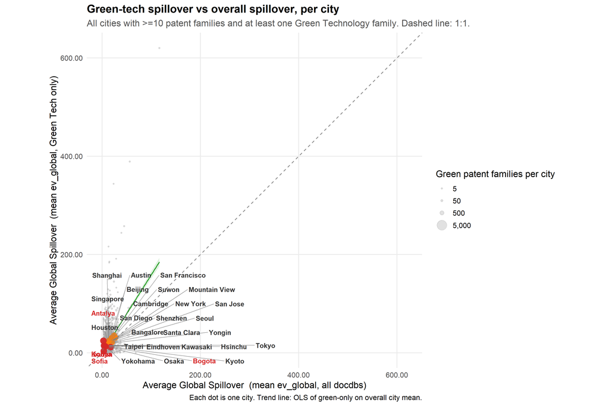

```
## OLS:  avg_ev_global_green = 0.2362 + 1.5825 * avg_ev_global
##   R^2 = 0.229, n = 5035 cities
```

```
## Cities where green > overall: 3,290 of 5,035 (65.3%)
```

## Top-of-table view

### 30 largest cities

`Share green` is the fraction of the city’s `# patents` that are flagged as Green Technology (via `tech_lookup.tech_group = "Green Technology"` or `technology = "Green Technology"`). `Green premium` is `Avg ev_global (green) / Avg ev_global` — values **greater than 1** mean the city’s green innovations have higher-than-average global spillover for that city.

| city | # patents | # green | Share green | Avg ev_global | Avg ev_global (green) | Green premium | Avg ev_emdenocn (LMICs) |
| --- | --- | --- | --- | --- | --- | --- | --- |
| Tokyo | 158,279 | 8,613 | 5.4% | 9.856 | 15.400 | 1.56 | 0.280 |
| Seoul | 86,798 | 6,325 | 7.3% | 15.721 | 20.970 | 1.33 | 0.418 |
| Beijing | 76,272 | 3,213 | 4.2% | 19.357 | 30.118 | 1.56 | 0.400 |
| Shenzhen | 75,348 | 2,970 | 3.9% | 17.426 | 23.295 | 1.34 | 0.372 |
| San Jose | 50,635 | 2,037 | 4.0% | 18.584 | 23.538 | 1.27 | 1.373 |
| Suwon | 50,466 | 2,601 | 5.2% | 13.811 | 21.249 | 1.54 | 0.444 |
| San Diego | 50,126 | 2,597 | 5.2% | 17.374 | 25.998 | 1.50 | 0.817 |
| Taipei | 49,426 | 2,300 | 4.7% | 9.661 | 13.720 | 1.42 | 0.269 |
| Shanghai | 41,507 | 2,254 | 5.4% | 14.168 | 24.951 | 1.76 | 0.399 |
| Osaka | 40,789 | 4,535 | 11.1% | 9.039 | 12.673 | 1.40 | 0.200 |
| Hsinchu | 32,166 | 1,057 | 3.3% | 7.756 | 14.905 | 1.92 | 0.265 |
| Bangalore | 31,358 | 1,609 | 5.1% | 14.383 | 21.310 | 1.48 | 1.540 |
| San Francisco | 28,744 | 829 | 2.9% | 24.605 | 35.403 | 1.44 | 1.697 |
| Yongin | 25,888 | 3,668 | 14.2% | 12.537 | 19.101 | 1.52 | 0.198 |
| New York | 25,657 | 1,123 | 4.4% | 17.288 | 23.645 | 1.37 | 1.095 |
| Singapore | 25,446 | 1,143 | 4.5% | 12.674 | 22.294 | 1.76 | 0.691 |
| Houston | 24,870 | 1,323 | 5.3% | 12.331 | 19.699 | 1.60 | 0.676 |
| Austin | 22,020 | 1,134 | 5.1% | 13.964 | 21.658 | 1.55 | 1.078 |
| Mountain View | 20,908 | 723 | 3.5% | 27.397 | 30.684 | 1.12 | 1.735 |
| Cambridge | 20,731 | 973 | 4.7% | 20.612 | 29.718 | 1.44 | 0.905 |
| Kyoto | 20,303 | 1,805 | 8.9% | 8.427 | 13.421 | 1.59 | 0.159 |
| Yokohama | 20,236 | 1,194 | 5.9% | 8.172 | 12.974 | 1.59 | 0.224 |
| Santa Clara | 19,462 | 983 | 5.1% | 20.435 | 21.078 | 1.03 | 1.374 |
| Kawasaki | 18,708 | 976 | 5.2% | 10.710 | 14.514 | 1.36 | 0.380 |
| Eindhoven | 18,633 | 941 | 5.1% | 9.966 | 13.311 | 1.34 | 0.434 |
| Seattle | 17,709 | 561 | 3.2% | 20.088 | 22.436 | 1.12 | 1.651 |
| London | 17,703 | 827 | 4.7% | 17.962 | 21.881 | 1.22 | 1.023 |
| Sunnyvale | 17,684 | 666 | 3.8% | 22.900 | 27.216 | 1.19 | 1.634 |
| Washington | 17,115 | 790 | 4.6% | 23.071 | 30.942 | 1.34 | 1.605 |
| Paris | 16,200 | 1,015 | 6.3% | 11.341 | 14.119 | 1.24 | 0.542 |

### Hand-picked label set

| city | # patents | # green | Share green | Avg ev_global | Avg ev_global (green) | Green premium | Avg ev_emdenocn (LMICs) |
| --- | --- | --- | --- | --- | --- | --- | --- |
| Sofia | 2,904 | 141 | 4.9% | 3.397 | 3.473 | 1.02 | 0.378 |
| Bogota | 251 | 11 | 4.4% | 17.244 | 11.350 | 0.66 | 1.278 |
| Antalya | 64 | 2 | 3.1% | 2.560 | 24.404 | 9.53 | 0.785 |
| Konya | 46 | 2 | 4.3% | 3.867 | 14.231 | 3.68 | 0.443 |
| Belem | 14 | 0 | 0.0% | 9.041 | NA | NA | 1.230 |
| Ibadan | 2 | 1 | 50.0% | 6.482 | 12.963 | 2.00 | 0.000 |
| Daanbantayan | 1 | 0 | 0.0% | 0.000 | NA | NA | 0.000 |

### Green premium across the highlighted cities

For each of the hand-picked cities the bar shows `(green_premium - 1) * 100` — the percentage by which a city’s green-tech innovations beat (or lag) the city’s overall mean `ev_global`. **Positive bars** = green innovations over-perform the city’s average; **negative bars** = green innovations underperform. The label on each bar carries the percentage, the total patent count, and the share of those that are flagged Green Technology, so a small denominator is easy to spot. Bars are coloured by sign.

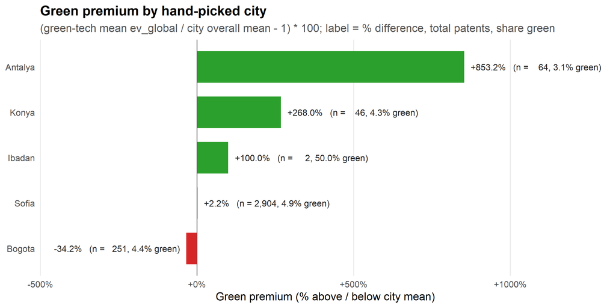

## Patent abstracts and OpenAI summaries

For each highlighted city, we retrieve the top-N patent applications (ranked by `ev_global`) via the EPO Open Patent Services (OPS) API, then ask `gpt-4o-mini` to summarise the technological themes that emerge from the titles + abstracts.

This section reuses the EPO/OPS plumbing from `insights/patent_cluster_compare.Rmd`. Two API keys are required as environment variables; if either is missing the section short-circuits to a warning rather than failing the knit.

```
## Will fetch up to 75 patents for each of 7 cities (total: 277).
```

```
## # A tibble: 7 × 4
##   city         requested titles abstracts
##   <chr>            <int>  <int>     <int>
## 1 Antalya             64     64        34
## 2 Belem               14     14         9
## 3 Bogota              75     74        60
## 4 Daanbantayan         1      1         1
## 5 Ibadan               2      2         0
## 6 Konya               46     46        26
## 7 Sofia               75     75        66
```

```
## # A tibble: 7 × 6
##   city         n_used_all n_used_top median_ev summary_all           summary_top
##   <chr>             <int>      <int>     <dbl> <chr>                 <chr>
## 1 Antalya              64         25      0    "Antalya's patent la… "Antalya's…
## 2 Belem                14          7      7.17 "In Belem, the paten… "The paten…
## 3 Bogota               75         37     19.6  "The patent landscap… "In Bogota…
## 4 Daanbantayan          1          0     NA    "Only 1 patent(s) re… "Top-innov…
## 5 Ibadan                2          0     NA    "Only 2 patent(s) re… "Top-innov…
## 6 Konya                46         22      0    "The patent landscap… "The paten…
## 7 Sofia                75         37     48.9  "The patents associa… "In Sofia,…
```

### Antalya

Open Antalya on HiGGlo (All innovations) →

**All fetched patents** — 64 with usable title/abstract text from OPS.

Antalya’s patent landscape reveals a diverse technological focus, with notable concentrations in healthcare, environmental technology, and innovative materials. A significant number of patents pertain to medical imaging and treatment methods, particularly in ophthalmology, showcasing advancements in fundus photography and eye treatment technologies. Additionally, there is a strong emphasis on environmental solutions, such as water purification systems and energy-efficient devices, indicating a commitment to sustainability and public health.

The breadth of innovation is striking, as the patents cover a wide range of applications, from agricultural advancements like hybrid crops to cutting-edge technologies in digital identity and blockchain systems. This variety suggests a vibrant ecosystem of inventors and researchers in Antalya, potentially linked to local universities or research institutions, although specific applicants are not explicitly mentioned in the abstracts. Overall, Antalya’s patent activity reflects a dynamic intersection of health, environmental sustainability, and technological innovation.

**Top innovations only** — 25 patents with `ev_global` above the median (median ev_global = 0.000).

Antalya’s patent landscape reveals a strong focus on healthcare technology, environmental solutions, and innovative materials. A significant number of patents pertain to advancements in ophthalmology, particularly methods for fundus photography, indicating a robust interest in improving eye care diagnostics. Additionally, there is a notable emphasis on environmental technologies, such as systems for water purification and grain storage that maintain optimal conditions for product preservation.

The diversity of patents suggests a surprising breadth in technological themes, ranging from medical devices to energy-efficient systems and agricultural innovations. This variety reflects a dynamic innovation ecosystem in Antalya, where different sectors are being explored simultaneously.

While specific institutions or applicants are not directly identifiable from the abstracts, the range of technologies implies collaboration among researchers and inventors in fields such as healthcare, environmental science, and materials engineering. This cross-disciplinary approach may foster further advancements and applications in these critical areas.

### Belem

Open Belem on HiGGlo (All innovations) →

**All fetched patents** — 14 with usable title/abstract text from OPS.

In Belem, the patent landscape reveals a strong focus on advanced optical technologies and telecommunications. A significant number of patents are centered around two-dimensional photonic crystals, which are utilized in devices for controlling electromagnetic signals, such as optical keys and nonreciprocal dividers. This indicates a robust interest in developing innovative solutions for integrated optical systems, showcasing a notable emphasis on magneto-optical materials and their applications in communication technologies.

Additionally, there is a distinct presence of patents related to food technology, specifically involving açai-based compositions, which highlights the region’s cultural and agricultural heritage. This blend of high-tech optical innovations alongside food-related patents illustrates a surprising breadth in the technological focus of Belem, reflecting both cutting-edge research and local traditions.

While specific notable applicants or institutions are not directly mentioned in the abstracts, the diversity of patent themes suggests a collaborative environment that may involve local universities or research institutions engaged in both technology and food science.

**Top innovations only** — 7 patents with `ev_global` above the median (median ev_global = 7.166).

The patents associated with Belem reveal a strong focus on advanced optical technologies and telecommunications. A significant theme is the development of photonic crystal devices, which are designed to manipulate electromagnetic signals for improved communication systems. This includes innovations like compact optical keys and nonreciprocal dividers that enhance signal control and distribution.

Another prominent area is the transmission technologies for base station systems, indicated by patents related to encoding and decoding methods, as well as non-linear precoding coefficients. These advancements suggest a commitment to improving data transmission efficiency and reliability in telecommunications.

Interestingly, there is also a unique inclusion of açaí-based food compositions, showcasing a blend of technological innovation with local cultural elements. This mix highlights a distinctive breadth in the patent landscape, combining high-tech developments with traditional food processing methods. While specific applicants or institutions are not detailed in the abstracts, the technical nature of the patents suggests involvement from entities focused on telecommunications and materials science.

### Bogota

Open Bogota on HiGGlo (All innovations) →

**All fetched patents** — 75 with usable title/abstract text from OPS.

The patent landscape in Bogotá reveals a strong focus on healthcare technologies, particularly in cancer detection and treatment prediction, as evidenced by multiple patents related to image analysis and machine learning applications in pathology. This includes innovations for detecting mitosis in cancerous tissues and predicting lung cancer recurrence based on histological images.

Additionally, there is a notable emphasis on financial technology, with several patents addressing creditworthiness assessment, loan issuance, and fraud detection using machine learning. This indicates a significant interest in enhancing financial services through advanced data analytics and artificial intelligence.

The mix of patents showcases a surprising breadth, spanning from healthcare to fintech, which suggests a diverse innovation ecosystem in Bogotá. While specific applicants or institutions are not explicitly mentioned in the abstracts, the advanced nature of the technologies implies involvement from research institutions or tech companies specializing in these fields. Overall, Bogotá’s patent activity reflects a commitment to leveraging technology for critical societal challenges in health and finance.

**Top innovations only** — 37 patents with `ev_global` above the median (median ev_global = 19.613).

In Bogota, the patents with high global spillover primarily focus on advanced healthcare technologies, artificial intelligence (AI), and financial services. A significant theme is the application of machine learning and deep learning techniques in medical diagnostics, particularly for cancer detection and prognosis. This includes innovative methods for analyzing pathology images and predicting patient responses to treatment.

Additionally, there is a notable emphasis on financial technology, with several patents addressing creditworthiness assessment and loan issuance using machine learning models. This reflects a growing trend in leveraging AI for improving financial services and consumer accessibility.

The mix of technologies is diverse, showcasing a strong concentration in healthcare innovations while also branching into areas like IoT and cybersecurity. This breadth indicates a vibrant innovation ecosystem in Bogota, with potential collaboration opportunities across sectors. While specific patent applicants or institutions are not explicitly mentioned, the advanced nature of the technologies suggests involvement from research institutions or tech companies specializing in AI and healthcare.

### Daanbantayan

Open Daanbantayan on HiGGlo (All innovations) →

**All fetched patents** — 1 with usable title/abstract text from OPS.

Only 1 patent(s) returned usable text from OPS — too few for a meaningful summary.

**Top innovations only** — 0 patents with `ev_global` above the median.

Top-innovations summary skipped (insufficient text returned from OPS).

### Ibadan

Open Ibadan on HiGGlo (All innovations) →

**All fetched patents** — 2 with usable title/abstract text from OPS.

Only 2 patent(s) returned usable text from OPS — too few for a meaningful summary.

**Top innovations only** — 0 patents with `ev_global` above the median.

Top-innovations summary skipped (insufficient text returned from OPS).

### Konya

Open Konya on HiGGlo (All innovations) →

**All fetched patents** — 46 with usable title/abstract text from OPS.

The patent landscape in Konya reveals a strong focus on innovations in firearms technology, agricultural machinery, and healthcare devices. A significant number of patents pertain to various firearm mechanisms, including adjustable gunstocks, trigger systems, and safety features for shotguns and rifles. This suggests a concentrated expertise in the design and functionality of hunting and sporting firearms.

Additionally, there is a notable presence of patents related to agricultural equipment, particularly systems for seed distribution and irrigation, indicating a commitment to enhancing agricultural efficiency. The healthcare sector is represented by patents for medical devices, such as a device for reversing anesthesia effects and a total artificial heart, showcasing advancements in medical technology.

Overall, the mix of patents demonstrates both a specialized focus on firearms technology and a surprising breadth in agricultural and healthcare innovations. While specific patent applicants or institutions are not explicitly mentioned, the diversity of technological themes suggests a vibrant innovation ecosystem in Konya, potentially driven by local inventors and industries.

**Top innovations only** — 22 patents with `ev_global` above the median (median ev_global = 0.000).

The patents associated with Konya reveal a strong focus on mechanical innovations, particularly in firearms and automotive technologies. A significant number of patents pertain to enhancements in gun mechanisms, such as adjustable gunstocks, trigger group lock systems, and assembly systems for shotguns and rifles. This indicates a concentrated expertise in firearm design and functionality.

Additionally, there is a notable presence of patents related to automotive systems, particularly air brake systems and trailer control mechanisms, showcasing advancements aimed at improving vehicle safety and efficiency.

The diversity of patents also extends to medical technologies, with inventions like a permanent total artificial heart device and methods for reversing local anesthesia, indicating a surprising breadth in the technological focus.

While specific applicants or institutions are not directly mentioned in the abstracts, the technical nature of the patents suggests involvement from inventors with specialized knowledge in engineering and medical fields. Overall, Konya’s patent landscape reflects a blend of mechanical engineering prowess with applications in both consumer products and healthcare.

### Sofia

Open Sofia on HiGGlo (All innovations) →

**All fetched patents** — 75 with usable title/abstract text from OPS.

The patents associated with Sofia reveal a strong focus on cloud computing technologies, particularly in areas such as cloud hosting systems, software-defined data centers, and automation of deployments. A significant number of patents emphasize load balancing, resource management, and the integration of multi-tenant cloud environments, indicating a robust interest in optimizing cloud infrastructure and services.

Additionally, there is a notable presence of innovations related to security and access control, such as facial recognition systems for building access and secure communication protocols for applications. This suggests a growing emphasis on enhancing security measures in technological solutions.

The diversity of patent themes is striking, as it spans from cloud management and automation to image rendering and environmental monitoring, showcasing a broad technological landscape. While cloud computing dominates, the inclusion of patents in areas like user authentication and data processing highlights a well-rounded innovation ecosystem. However, specific applicants or institutions are not readily identifiable from the abstracts provided, indicating a mix of contributors in this vibrant technological environment.

**Top innovations only** — 37 patents with `ev_global` above the median (median ev_global = 48.906).

In Sofia, the patents with high global spillover predominantly focus on cloud computing technologies, automation, and advanced data processing methods. A significant theme is the development of cloud hosting systems that emphasize load balancing, scaling, and efficient resource management, indicating a strong emphasis on optimizing cloud infrastructure. Additionally, there is a notable concentration on automation in software deployment and database management, showcasing efforts to enhance operational efficiency in cloud environments.

The breadth of technologies is impressive, as it spans from facial recognition access systems to innovative methods for rendering images and managing virtual machines across different platforms. This diversity suggests a vibrant tech ecosystem that is not limited to a single niche but rather encompasses various aspects of modern computing and data management.

While specific patent applicants or institutions are not explicitly mentioned, the complexity and technical depth of the patents imply involvement from advanced tech companies or research institutions, likely reflecting Sofia’s growing reputation as a hub for innovation in technology.

## Firm word cloud per city

These wordclouds use the **raw PATSTAT person + appln tables** from the local Dropbox export (`patstat_clean/tls206_person.parquet` and `tls207_pers_appln.parquet`). For each highlighted city we:

1. Resolve the city’s docdb set via `countrymap.parquet` (which is itself derived from those same PATSTAT person addresses, so any docdb the app sees attached to the city has at least one person record we can read here).
2. Look up every applicant / holder person on those docdbs in `tls207_pers_appln`.
3. Apply a firm-detection regex (legal-form suffixes like `INC / CORP / GMBH / SARL / KK / OY / SPA / LTD / UNIVERSITY / INSTITUTE / FOUNDATION` etc.) to filter out individuals.
4. Send the unique firm names to `gpt-4o-mini` for canonical harmonisation (`Robert Bosch GmbH` + `Bosch Sensortec` → `Bosch`), keyed and cached on disk so repeat knits skip the LLM call.
5. Render one wordcloud per city, plus a top-10 firms table.

This is more inclusive than the previous `patents_x_firm.parquet` view (which was top-100 only), and unlike the EPO OPS pass it doesn’t depend on which patents OPS happens to surface — every docdb in the bundle has at least one applicant row in PATSTAT.

```
## raw holder rows: 5,573   unique names: 5,564   cities with hits: 7 / 7
```

```
## after firm filter: 463 rows  460 unique firm names  cities with firms: 5 / 7
```

```
## after harmonisation: 103 rows kept across 5 cities
```

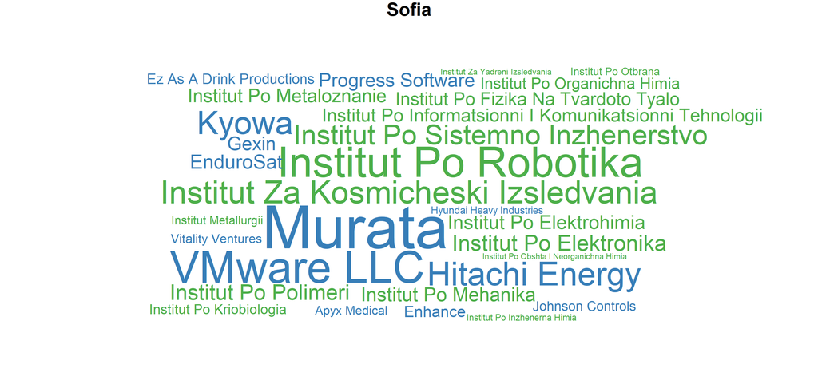

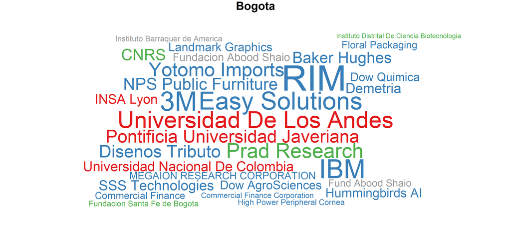

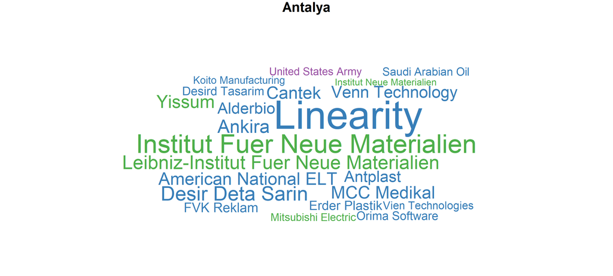

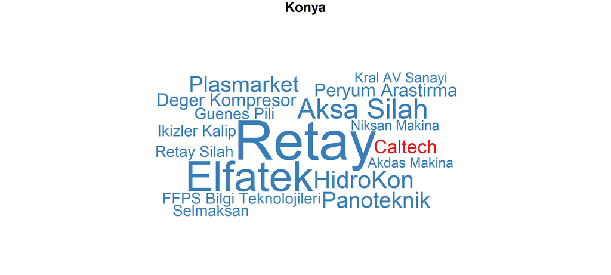

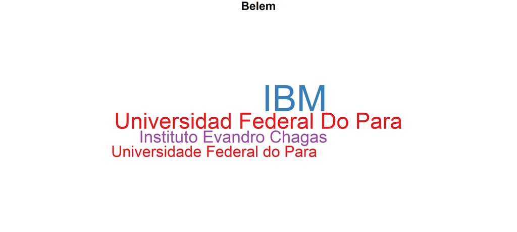

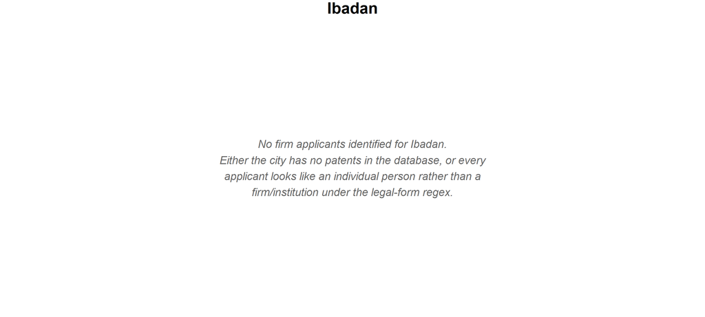

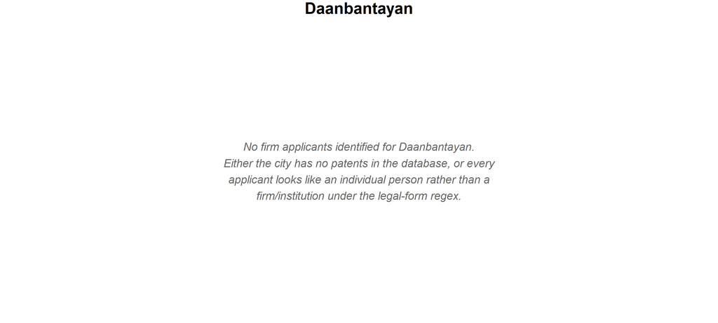

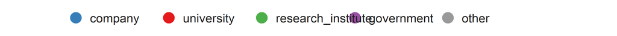

[output not shown]

## HiGGlo network: per highlighted city

For each of the hand-picked / highlighted cities we capture the HiGGlo citation-network view directly from the live app via headless Chrome (`chromote`). Same parameters as the URL the user provided for Sofia:

- City filter: the hand-picked city
- `toflow = ev_global`, no firm/tech filter, **All countries**
- Gen-0 sampling: Random / Number / 100
- Edge sampling: Random / Percent / 100
- `add_generations = 2` (one Generate click → gens 1 and 2)

PNGs are cached under `.bigdata/innocity/higglo_<city>.png`. To force any one of them to refresh, delete the corresponding file and re-knit. The first run captures all of them sequentially in a single chromote session (re-using the warm Shiny server between navigations); budget ~50-70 s per city for a cold first knit, near zero on subsequent knits.

### Sofia

#### Sofia — All innovations

Open Sofia on HiGGlo (All innovations) →

[figure not shown]

#### Sofia — Green Technology

Open Sofia on HiGGlo (Green Technology) →

[figure not shown]

### Bogota

#### Bogota — All innovations

Open Bogota on HiGGlo (All innovations) →

[figure not shown]

#### Bogota — Green Technology

Open Bogota on HiGGlo (Green Technology) →

[figure not shown]

### Antalya

#### Antalya — All innovations

Open Antalya on HiGGlo (All innovations) →

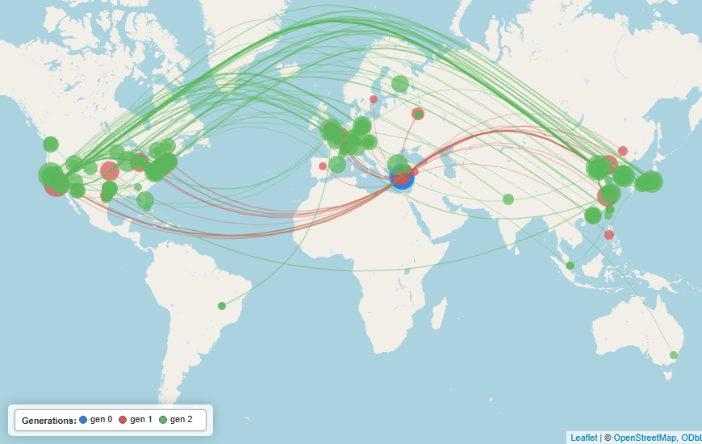

#### Antalya — Green Technology

Open Antalya on HiGGlo (Green Technology) →

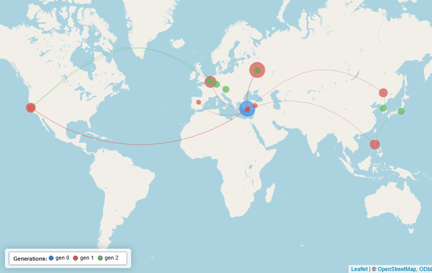

### Konya

#### Konya — All innovations

Open Konya on HiGGlo (All innovations) →

[figure not shown]

#### Konya — Green Technology

Open Konya on HiGGlo (Green Technology) →

[figure not shown]

### Belem

#### Belem — All innovations

Open Belem on HiGGlo (All innovations) →

[figure not shown]

#### Belem — Green Technology

Open Belem on HiGGlo (Green Technology) →

[figure not shown]

### Ibadan

#### Ibadan — All innovations

Open Ibadan on HiGGlo (All innovations) →

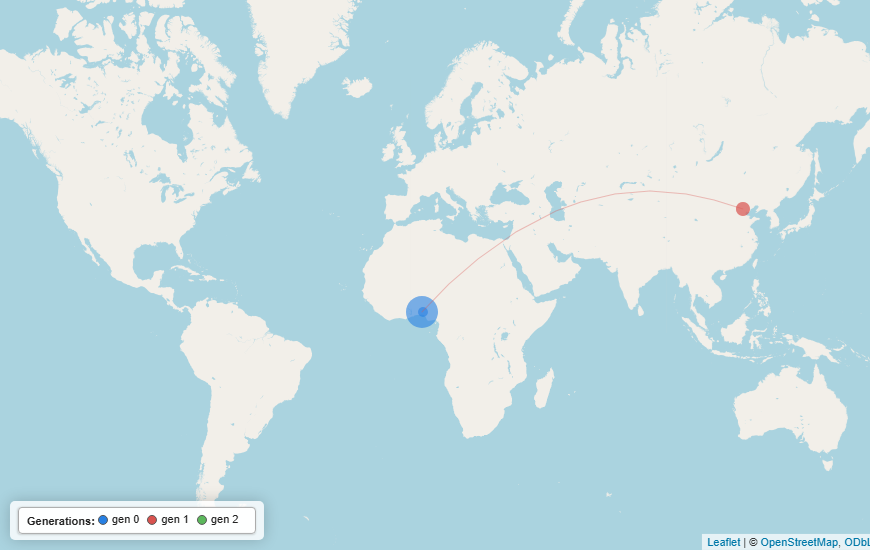

#### Ibadan — Green Technology

Open Ibadan on HiGGlo (Green Technology) →

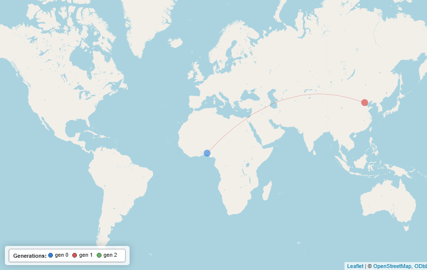

### Daanbantayan

#### Daanbantayan — All innovations

Open Daanbantayan on HiGGlo (All innovations) →

[figure not shown]

#### Daanbantayan — Green Technology

Open Daanbantayan on HiGGlo (Green Technology) →

[figure not shown]

*Notes.*

- `ev_global` is the Watson per-family expected spillover to the whole world; `ev_emdenocn` is the share of that spillover that lands in LMICs excluding China. Both are docdb-level (one value per family), so per-city averages are unweighted means across the families associated with the city through `countrymap`.
- Capital-fallback rows (`geocode_missing = TRUE`) are dropped before aggregation. Without that, every patent for which no real address survived geocoding would inflate the patent count of the country’s capital.
- A single docdb may be mapped to multiple cities (e.g. multinational inventor teams). Each city it touches gets credit for the family — there is no proportional split.
- The abstract-fetch + OpenAI summary section caches both OPS responses and OpenAI completions under `.bigdata/innocity/`, keyed on the cities and the per-city patent set. Re-knitting the document is free as long as the inputs don’t change. Delete files in that directory to force a refetch / re-summarise.
- Default scope is the seven hand-picked cities only. To also summarise the 25 biggest cities, edit `cities_to_summarise` in the `summary_helpers` chunk — but expect a very long OPS fetch the first time round, since each big city sends `max_per_city` HTTP calls.